# NGS Workshop

## 7.3 Generating Alignment Statistics

When aligning reads to the reference genome anywhere between 0 to 20% of reads are not aligned due to sequencing errors, sample contamination (e.g. bacterial or viral DNA), gaps in the reference genome and genome variation. Use `samtools flagstat` to determine how many reads have been aligned. We will compare the duplicate-marked `bam` file with the final filtered `bam` file.

1. In the Tool Panel select the `Samtools flagstat tabulate descriptive stats for BAM datset` tool.
2. Select `Dataset collection` as your data type, then select `MarkDuplicates on collection 20: BAM` as your data collection.
3. Click on the `Run Tool` button to execute the analysis.
4. Run the `Samtools flagstat` tool again for the `Filter SAM or BAM, output SAM or BAM on collection 23: bam` dataset.

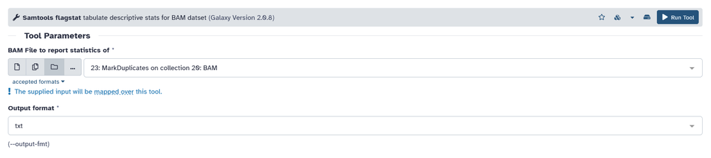

Figure 33: The `samtools flagstat` tool panel, with the duplicate-marked `bam` file loaded as input

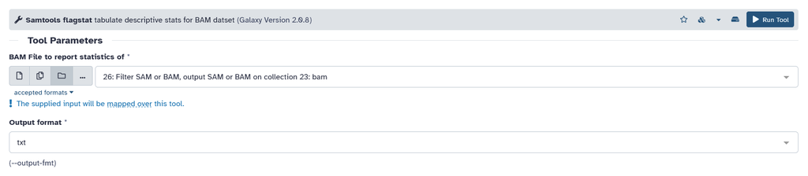

Figure 34: The `samtools flagstat` tool panel, with the filtered `bam` file loaded as input

**Important**

Click the view data icon for both and use the Flagstat output to determine the percentage of mapped reads, and calculate the number of reads that were filtered out (difference in total read count between the raw and filtered BAM files).

**Before Filtering**

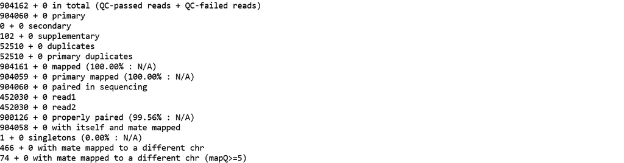

Figure 35: Statistics for the duplicate-marked `bam` file, calculated by `samtools flagstat`

**After Filtering**

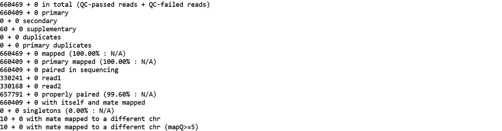

Figure 36: Statistics for the filtered `bam` file, calculated by `samtools flagstat`

#### 7.3.0.1 Questions

**Important**

Use the `samtools flagstat` outputs for the duplicate-marked (before filtering) and filtered (after filtering) `bam` files to answer the following questions.

For questions 1–5, type your answer in the box and press `Check`. For the multiple choice questions (6–9), click on an option to check your answer.

1. How many reads (in total) does the `bam` file contain before filtering?

   The duplicate-marked `bam` file contains 904,162 reads. Of these, 904,060 are *primary* alignments, exactly the number of reads `fastp` kept after filtering: every read in the `fastq` files gets one primary alignment. The other 102 are *supplementary* alignments, extra records for reads whose parts align to different places in the genome.
2. What percentage of reads were mapped to the reference genome before filtering? (Round to the nearest whole number.)

   904,161 of the 904,162 reads (100.00%) were mapped, so only a single read was left unmapped. This is higher than you would usually expect, and this is because the workshop dataset was made by extracting reads that had already aligned to chromosome 22.
3. How many reads were filtered out?

   904,162 − 660,469 = 243,693 reads were filtered out.
4. What percentage of the reads were filtered out? (Round to the nearest whole number.)

   243,693 / 904,162 × 100 ≈ 27% of the reads were filtered out, leaving 73% of the reads for variant calling.
5. What percentage of the primary reads were flagged as duplicates by `MarkDuplicates`? (Round to one decimal place.)

   52,510 / 904,060 × 100 ≈ 5.8% of the primary reads were flagged as duplicates. After filtering there are 0 duplicates, because we discarded reads with the `The read is a PCR or optical duplicate` flag set.
6. Duplicates account for most of the reads that were filtered out. Which filter removed most of the remaining reads?
   - The read is unmapped
   - The alignment or this read is not primary
   - The read fails platform/vendor quality checks
   - Minimum MAPQ quality score of 30

   Before filtering there was only 1 unmapped read, 0 secondary alignments and 0 reads failing quality checks (the second number on each line, after the `+`).

   The rest of the reads, about 191,000 (~21% of the total), were removed because their mapping quality (MAPQ) was below 30.

   MAPQ is a Phred-scaled estimate of the probability that a read has been aligned to the wrong place: MAPQ 30 means a 1 in 1,000 chance. Reads that align equally well to several places in the genome, such as repeats, segmental duplications and closely related genes (paralogues) get a low MAPQ, as the aligner cannot tell where they really come from.
7. Before filtering, there are the same number of `read1` and `read2` reads (452,030), but after filtering there are 330,241 `read1` and 330,168 `read2` reads. Why?
   - `fastp` discarded some unpaired reads
   - `BWA-MEM` failed to align some of the `read2` reads
   - The filters are applied to each read individually, so one read of a pair can be removed while its mate is kept
   - `samtools flagstat` counts `read2` incorrectly

   `samtools` checks the MAPQ and flags of each read on its own. If one read of a pair aligns to a repetitive region and gets a low MAPQ, it is removed, but its mate is kept if it passes the filters. The line `with itself and mate mapped` still reports 660,409 reads, because it is based on each read’s flags, which record that its mate was mapped, even if the mate is no longer in the file.
8. Why are there still 60 *supplementary* alignments after filtering, even though we skipped alignments that are `not primary`?
   - The `not primary` flag marks *secondary* alignments; supplementary alignments have their own flag, which we did not select
   - They are duplicates that `MarkDuplicates` did not detect
   - They are unmapped reads
   - `samtools` cannot remove supplementary alignments

   A *secondary* alignment is an alternative position for a read that aligns to more than one place. A *supplementary* alignment is a part of a read (a split or chimeric read) that aligns to a different place from the rest of it, for example across a deletion or structural variant.

   They are marked by different flags, so skipping `The alignment or this read is not primary` does not remove supplementary alignments. To remove them, you would also need to select `The alignment is supplementary`.
9. After filtering, the percentage of properly paired reads rises slightly (99.56% to 99.60%), and the number of reads `with mate mapped to a different chr` falls from 466 to 10. What does this suggest?
   - Filtering has introduced alignment errors
   - Many of the reads with unexpectedly placed mates were ambiguous alignments, which were removed by the MAPQ filter
   - The sample carries hundreds of translocations between chromosomes
   - Duplicate reads always have mates on a different chromosome

   A read pair is *properly paired* when both reads align facing each other, on the same chromosome, at about the expected distance apart. Pairs whose mates align to different chromosomes are sometimes caused by real structural variants, but are more often caused by reads from repetitive regions that have been aligned to the wrong place. Of the 466 such reads, only 74 had a MAPQ of 5 or higher, and only 10 passed our MAPQ 30 filter, so most were low-confidence alignments.

## 7.4 Viewing the BAM File

As mentioned above, the `bam` file is held in binary format and so it can not be viewed directly.

However, the `bam` file can be converted to a viewable text format known as a SequenceAlignment/Map file or `sam` file. The `sam` file format is described in detail [here](https://samtools.github.io/hts-specs/SAMv1.pdf).

Let’s use `samtools view` to convert the filtered `bam` file to a `sam` file so we can view its contents.

1. In the Tool Panel select the `Samtools view` tool.
2. Select `Dataset collection` as your data type, then select `Filter SAM or BAM, output SAM or BAM on collection 23: bam` as your data collection.
3. In the `Output format` select the option`SAM`.
4. Click on the `Run Tool` button to execute the conversion.
5. Click view data to view the SAM file.

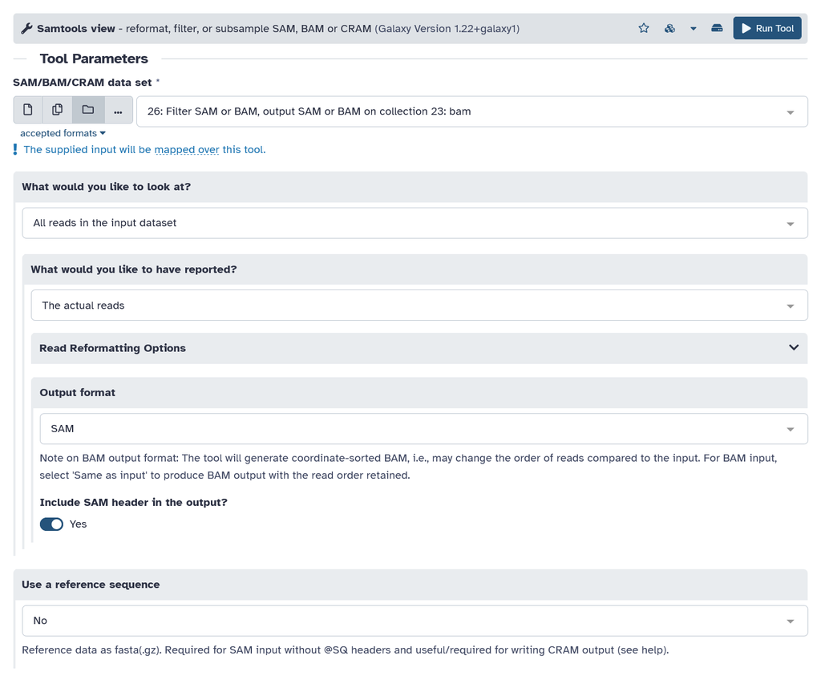

Figure 37: The `samtools view` tool panel with options set to convert the filtered `bam` file to `sam` format

8. Spend some time inspecting this file and its contents and format.
9. **Optional.** Repeat the conversion step but exclude the SAM header by disabling `Include SAM header in the output?`. This will make it easier to view the aligned reads.

### 7.4.1 The SAM/BAM Format

In the SAM file, lines starting with “@” are headers, and those without “@” are read sequences aligned to the reference.

| **SAM_Column** | Description |
| --- | --- |
| **QNAME** | Query name of the read or the read pair |
| **FLAG** | Bitwise flag (pairing) |
| **RNAME** | Reference sequence name |
| **POS** | 1-Based leftmost position of clipped alignment |
| **MAPQ** | Mapping quality (Phred-scaled) |
| **CIGAR** | Extended CIGAR string (operations MIDNSHP) |
| **MRNM** | Mate reference name (‘=’ if same as RNAME) |
| **MPOS** | 1-based leftmost mate position |
| **ISIZE** | Inferred insert size |
| **SEQQuery** | Sequence on the same strand as the reference |
| **QUAL** | Query quality (ASCII-33=Phred base quality) |

Please see the following two reads. Note that they both have the same read id. `HWI-D00119:50:H7AP8ADXX:1:1107:11894:71970`

```
HWI-D00119:50:H7AP8ADXX:1:1107:11894:71970  99  chr1    143252916   60  64M =   143252916   64  GATTCCATTCCATACCATTTGAAGATGATTACATTCGAGACCATTAGATGATTGCATTCAATTC    @CCFFFDDFHHGHIIIEEHIIIIEDDEEEHGIGEDHIAEFHHGIGHG>GDBDFHIGGCHHGGEH    MC:Z:64M MD:Z:30C14C18 PG:Z:MarkDuplicates RG:Z:HWI-D00119.50.H7AP8A…

HWI-D00119:50:H7AP8ADXX:1:1107:11894:71970  147 chr1    143252916   60  64M =   143252916   -64 GATTCCATTCCATACCATTTGAAGATGATTACATTCGAGACCATTAGATGATTGCATTCAATTC    IGIGGHFDGGGDDBHGGBIGHFAEEDEDGFBIGIHCGDECGIIHGIHBIIHDHDHFDDFFD@@C    MC:Z:64M MD:Z:30C14C18 PG:Z:MarkDuplicates RG:Z:HWI-D00119.50.H7AP8A…
```

**SAM/BAM Format mapping:**

**QNAME**: HWI-D00119:50:H7AP8ADXX:1:1107:11894:71970  
**FLAG**: 99  
**RNAME**: chr1  
**POS**: 143252916  
**MAPQ**: 60  
**CIGAR**: 64M  
**MRNM**: =  
**MPOS**: 143252916  
**ISIZE**: 64  
**SEQQuery**: GATTCCATTCCATACCATTTGAAGATGATTACATTCGAGACCATTAGATGATTGCATTCAATTC  
**QUAL**: @CCFFFDDFHHGHIIIEEHIIIIEDDEEEHGIGEDHIAEFHHGIGHG>GDBDFHIGGCHHGGEH

**Important**

Use [this website](https://broadinstitute.github.io/picard/explain-flags.html) to decode the flags (99 and 147) of the reads and determine which strand of the reference genome they are aligned with.

## 7.5 Compressing the BAM File

While `bam` files are already compressed, further compression is possible using the `cram` format. `cram` (Compressed Read Alignment Map) is a more efficient file format that compresses alignment data by storing only the differences between the reads and the reference genome, rather than storing the full sequence data.

1. In the Tool Panel select the `samtools view` tool.
2. Select `Dataset collection` as your data type, then select `Filter SAM or BAM, output SAM or BAM on collection 23: bam` as your data collection.
3. In the `Output format` select the option `CRAM (-C)`.
4. In the section `Use a reference sequence?`, select `Use a built-in genome` and then for the reference genome, select `Human Dec. 2013 (GRch38/hg38)`.
5. Click on the `Run Tool` button to execute the conversion.

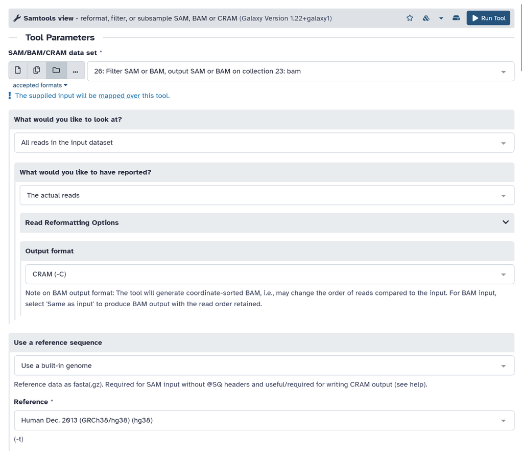

Figure 38: The `samtools view` tool panel with options set to convert the filtered `bam` file to `cram` format

#### 7.5.0.1 Questions

**Important**

Once the `cram` file has been generated, compare the file sizes of the `bam` and `cram` files to answer the following questions.

1. In your History panel, click on the `bam` file dataset from `Filter SAM or BAM, output SAM or BAM on collection 23: bam` and note the file size displayed.
2. Click on the `cram` file dataset from `Samtools view on dataset 27: filtered alignments` and note the file size displayed.

For questions 1 and 2, type your answer in the box and press `Check`. For the multiple choice questions (3–5), click on an option to check your answer.

1. How much space (in MB) has been saved by converting the `bam` file to `cram` format?

   The filtered `bam` file is 47.3 MB and the `cram` file is 26.1 MB, so 47.3 − 26.1 = 21.2 MB has been saved.
2. What percentage of space has been saved by converting to `cram` format? Use the formula (`bam` size − `cram` size) / `bam` size × 100%. (Round to the nearest whole number.)

   (47.3 − 26.1) / 47.3 × 100 ≈ 45%. The `cram` file is a little over half the size of the `bam` file, about 1.8 times smaller.
3. How does the `cram` format make the file smaller than the `bam` format?
   - It removes the unmapped and duplicate reads
   - It discards the base quality scores
   - It stores only the differences between each read and the reference genome, instead of the full read sequence
   - It keeps only the reads that align to chromosome 22

   Most bases in a read match the reference genome, so `cram` only needs to record where each read aligns and the few bases that differ from the reference. By default, `cram` compression is *lossless*: the `cram` file contains the same reads, quality scores and alignment information as the `bam` file, and the `bam` file can be recreated from it exactly.
4. A colleague wants to open your `cram` file on their own computer. Apart from the `cram` file, what do they need?
   - The original `fastq` files
   - The `bam` file it was made from
   - The same reference genome (hg38) that was used to create the `cram` file
   - Nothing else, the `cram` file is self-contained

   As the `cram` file stores the reads as differences from the reference genome, the read sequences cannot be rebuilt without the exact same reference sequence.

   If a different reference (for example hg19, or a version of hg38 with different chromosome names) is used, the file cannot be decoded correctly.

   This is why it is important to keep a record of which reference genome was used for alignment.
5. Even though the read sequences are stored very efficiently, the `cram` file is still more than half the size of the `bam` file. Which part of the data takes up most of the space in the `cram` file?
   - The read sequences
   - The base quality scores
   - The `bam` header
   - The read group information

   Comparing reads to the reference genome greatly reduces the space needed for the read sequences, but each base still has its own quality score, and these are much harder to compress. Quality scores can take many different values and vary a lot between neighbouring bases, so they make up most of a lossless `cram` file.

   Nowadays newer sequencer models *bin* quality scores into a few values (for example, 2, 12, 23 and 37), which compress much better.

   `cram` files can also use *lossy* compression, binning or discarding quality scores to save more space, at the cost of losing some information.

**Note**

`cram` files are particularly useful for large-scale sequencing projects where storage and transfer costs can become significant.

## 7.6 Generate alignment statistics per chromosome

When viewing the SAM file you may have noticed that not all the reads are mapped to chromosome 22 which is surprising as the sequence was initially filtered for reads mapping to chromosome 22 only. Use the IdxStats to generate a breakdown of the number of reads that map to each chromosome or contig.

1. In the Tool Panel select the `Samtools idxstats` tool.
2. Select `Dataset collection` as your data type, then select `Filter SAM or BAM, output SAM or BAM on collection 23: bam`, or the `cram` file we just generated in `Samtools view on collection 26: filtered alignments`, as your data collection.
3. Click on the `Run Tool` button to execute the analysis.
4. Click on `View` when the job has finished running.

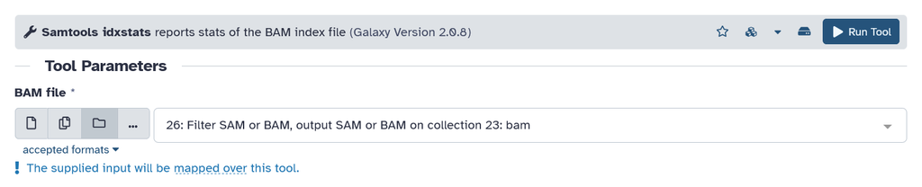

Figure 39: The `samtools idxstats` tool panel

This will produce a file with 4 columns:

1. Reference sequence identifier
2. Reference sequence length
3. Number of mapped reads.
4. Number of placed but unmapped reads (typically unmapped partners of mapped reads)

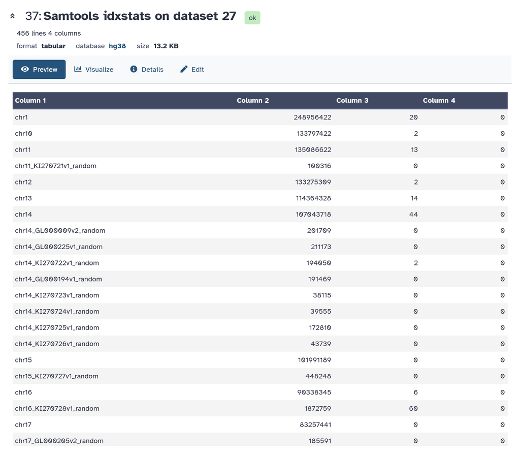

Figure 40: The `samtools idxstats` output

#### 7.6.0.1 Questions

**Important**

Use the `idxstats` output to answer the following questions. The total number of mapped reads can be found in the `samtools flagstat` output for the filtered `bam` file.

For question 1, type your answer in the box and press `Check`. For the multiple choice question (2), click on an option to check your answer.

1. What percentage of the mapped reads in the filtered `bam` file map to chromosome 22? (Round to one decimal place.)

   651,474 of the 660,469 mapped reads map to chromosome 22: 651,474 / 660,469 × 100 ≈ 98.6%. The remaining 8,995 reads (1.4%) map to other chromosomes and contigs.
2. The workshop dataset was made by extracting reads that aligned to chromosome 22. Why do some of these reads now map to other chromosomes and contigs?
   - The reads were originally extracted using a different reference genome
   - The reads were contaminated with DNA from another sample
   - `MarkDuplicates` moved some reads to other chromosomes
   - `samtools idxstats` counts the reads incorrectly

   In this case, the reads were originally extracted from an alignment to the hg19/GRCh37 reference genome, and in this workshop we aligned them to hg38/GRCh38. A read mapping to chromosome 22 in hg19 is not guaranteed to be on chromosome 22 in hg38.

   Where a read aligns depends on the reference genome version and the aligner used. Many regions of chromosome 22 have similar sequences elsewhere in the genome, such as paralogous genes, segmental duplications and the unplaced (`_random`) and unlocalised (`chrUn_`) contigs of hg38. When the reads are aligned again to the whole hg38 genome, some of them find a better match outside chromosome 22.

   As we kept only reads with a MAPQ of at least 30, these reads were placed there with high confidence.

## 7.7 Determine the distribution of insert sizes

Insert sizes, the region between the 5’ ends of the paired reads (see Figure 41), are important for correct alignment and variant calling. For variant calling, reads are assumed to be independent.

However, if an insert is smaller than the sum of the read pairs the reads will overlap and not be independent in the overlapping region (shown in yellow).

If a PCR error occurs in this overlapping region it will be present in both reads which may result in there being enough evidence to call a variant at this site that is not real.

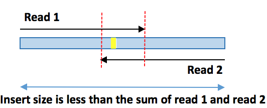

Figure 41: Diagram to show the construction of a fragment where an insert size is shorter than the length of both reads.

Picard `CollectInsertSizeMetrics` provides data on the Insert Size, including the parts covered by the reads and the unsequenced gap in the middle.

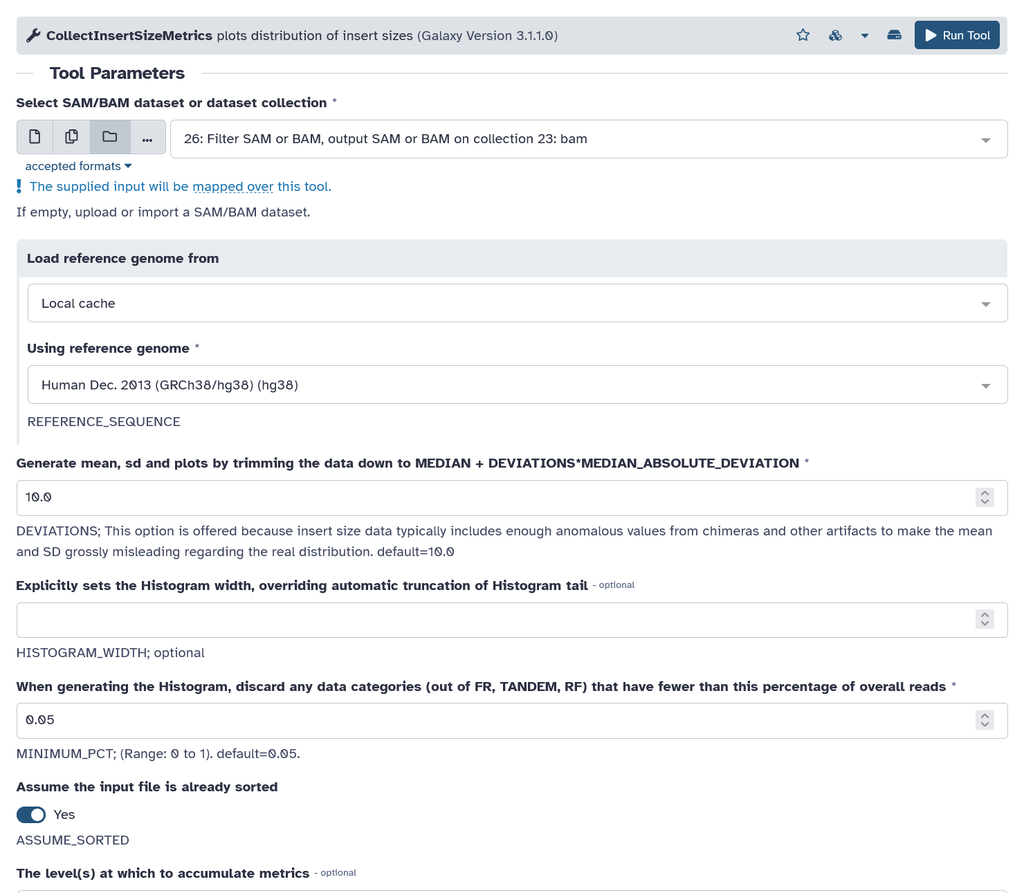

Figure 42: The `CollectInsertSizeMetrics` tool panel with options set

This tool will produce two output files. The first is a tabular output with some metrics and a list of insert sizes and counts. The second output is a .pdf with a insert size histogram, that should look like Figure 43.

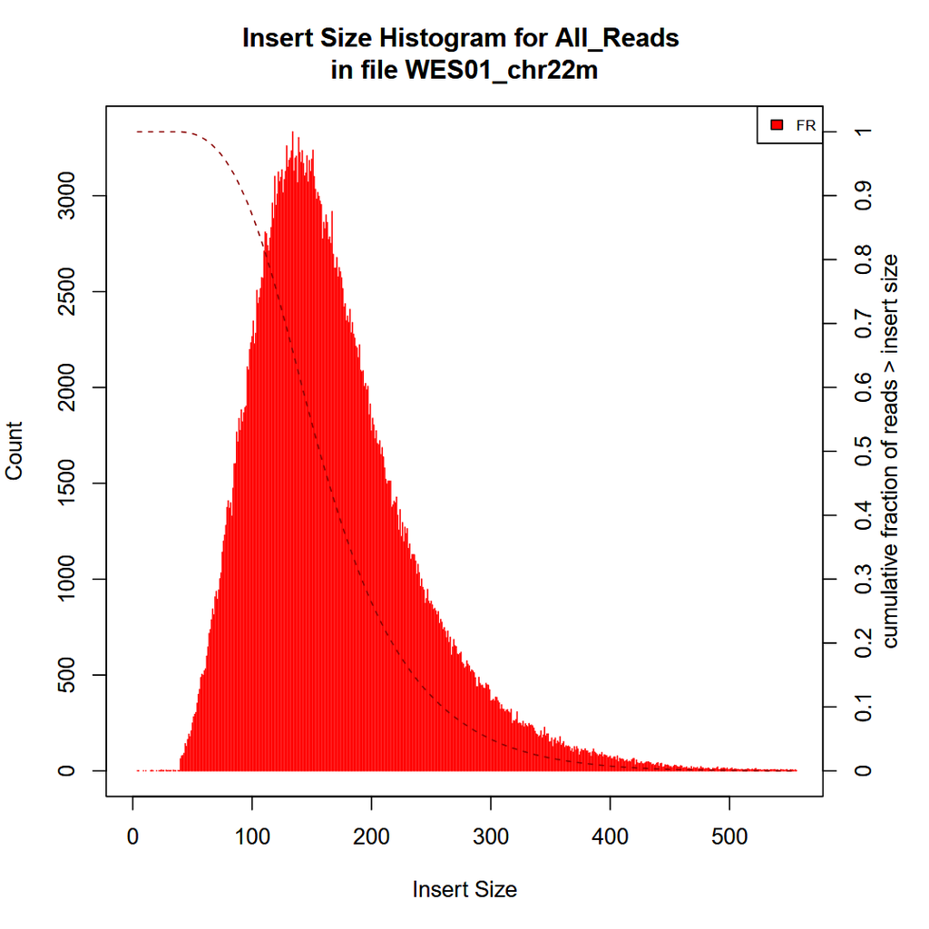

Figure 43: The `CollectInsertSizeMetrics` output histogram, showing the distribution of insert sizes on the aligned reads

The aspects to look out for here depend on the experiment.

In **WGS**, the goal is uniform coverage, so the ideal insert target range is usually **350bp - 500bp**. With 2x100bp reads, a 350bp insert leaves a ~150bp gap between reads, which provides good physical coverage for spanning repetitive regions or detecting deletions.

What to watch out for:

- You want a sharp bell curve, as a tight distribution allows structural variant callers (which rely on deviations from the expected insert size) to work accurately.
- If the histogram is very wide, the library size selection was poor.
- Bimodality (two distinct peaks in the histogram) usually means two different library preps were mixed, or there was a problem with fragment selection during library preparation.

In **WES** the goal is capturing coding regions efficiently, so the ideal insert target range is lower at around **150bp - 250bp**. This is because exome capture probes work best on specific fragment sizes. If fragments are too large, they may overlap into intronic regions, and if they are too small, the probes may not bind well.

What to watch out for:

- If your median is very low (e.g., 130bp), your reads overlap significantly. While you will get high-confidence variant calling in the overlap, the data may generate false positive variants, as seen above (Figure 41), and there was a waste in sequencing capacity, since there was less than 200bp of data per read pair.
- Look at the very left of the histogram. A sharp spike near ~0-30bp often indicates adapter dimers, i.e., empty molecules composed of two adapters joined together without a fragment between them. This wastes sequencing reads with bad data.

**Important**

1. View the tabular output and record the mean insert size and standard deviation.
2. Compare the histogram generated on the aligned data by `CollectInsertSizeMetrics`, with the histogram generated on the raw sequencing data by `fastp`. Why are there differences between the two plots?

## 7.8 Depth of Coverage

Identification and accuracy of variant calling relies on the depth and breadth of sequence coverage. To calculate coverage, a file in bed format describing the target region is required. Bed files use tab delimited columns of data to describe the target: chromosome, left location (bp), right location (bp).

### 7.8.1 Calculate depth per base

We will use the uploaded bed file which describes the exome sequence that has been targeted in your trial data `chr22.genes.hg38.bed`.

The options we selected will report the per-base of coverage for each feature in the `bed` file.

1. In the Tool Panel select the `bedtools Compute both the depth and breadth of coverage` tool.
2. Switch the tool software version to `2.22.1`.
3. For the `Count how many intervals in this BED/VCF/GFF/BAM file (source)` section select `Dataset collection` as your data type, then select `Filter SAM or BAM, output SAM or BAM on collection 23: bam` as your data collection.
4. For the `overlap the intervals in this BED file (target)` select the `chr22.genes.hg38.bed` file.
5. Enable the option `Report the depth at each position in each B feature`.
6. Click on the `Run Tool` button to execute the analysis.

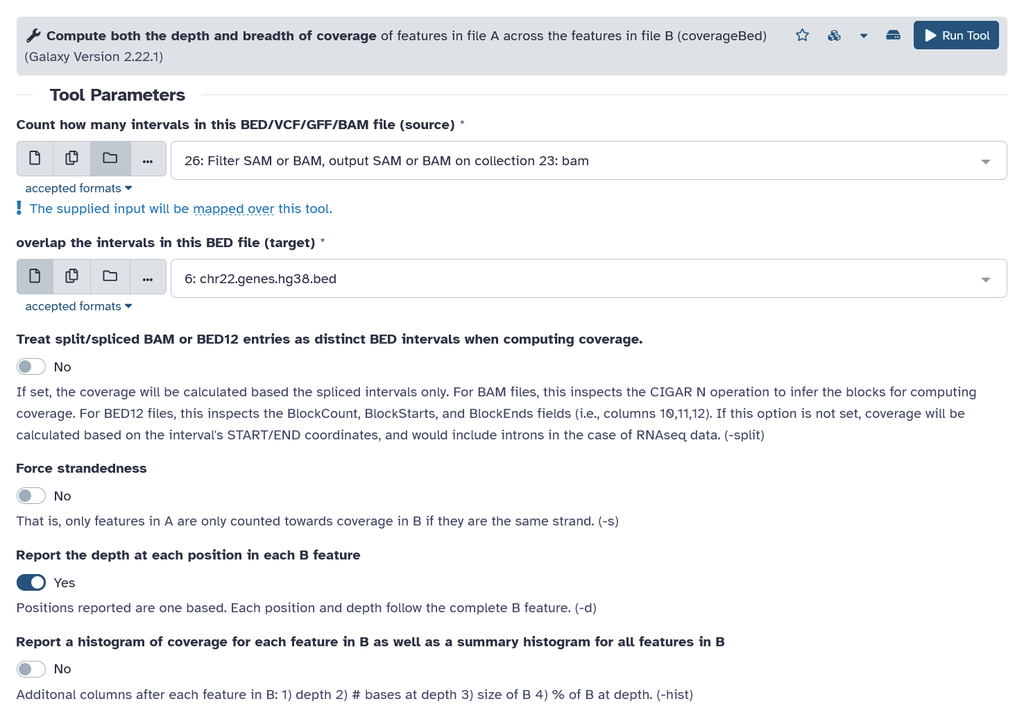

Figure 44: The `bedtools Compute both the depth and breadth of coverage` version `2.22.1` tool panel with options set

The output will consist of a line for each one-based position in each feature, followed by the coverage detected at that position.

The 6th (last) column is the **Depth** at position X (Column 5) for the genomic feature (exon) A (columns 1-4).

Note that the order in column 5 is not numerical or in order. This is a quirk of `bed` files’ sorting.

```
chr22   15528158    15529137    OR11H1-chr22-16448826-16449804  1   23
chr22   15528158    15529137    OR11H1-chr22-16448826-16449804  10  33
chr22   15528158    15529137    OR11H1-chr22-16448826-16449804  100 65
```

For line 1: the depth at the first base (indicated by col 5) of the feature/exon OR11H1-chr22-16448826-16449804 is 23. For line 2: the depth at the 10th base (indicated by col 5) of the feature/exon OR11H1-chr22-16448826-16449804 is 33. For line 3: the depth at the 100th base (indicated by col 5) of the feature/exon OR11H1-chr22-16448826-16449804 is 65.

### 7.8.2 Correct the sort order

7. In the Tool Panel select the `Sort data in ascending or descending order` tool.
8. For the `Sort Query` section select `Dataset collection` as your data type, then select `Compute both the depth and breadth of coverage across collection 26` as your data collection.
9. In `Column selections`, Click `+ Insert Column Selections` twice.
10. Add `Sort on Column 2` Leave all the other options as they are.
11. Add `Sort on Column 5` Leave all the other options as they are.
12. Click on the `Run Tool` button to execute the analysis.

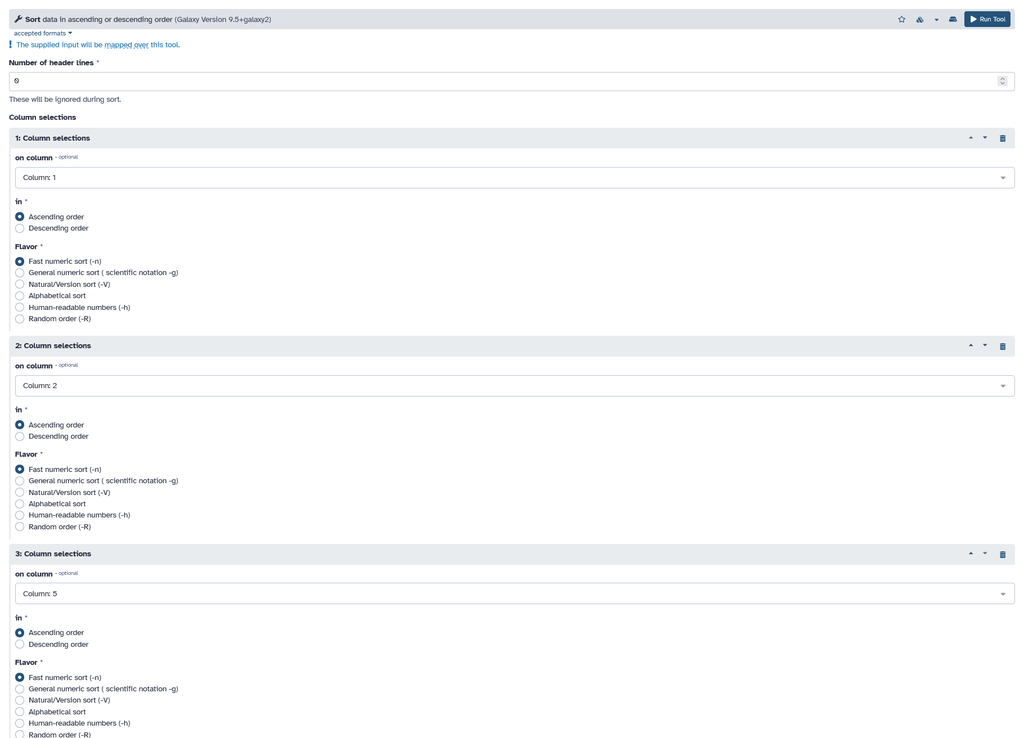

Figure 45: The `Sort data in ascending or descending order` tool panel with options set

13. View the new sorted data. It should look like Figure 46.

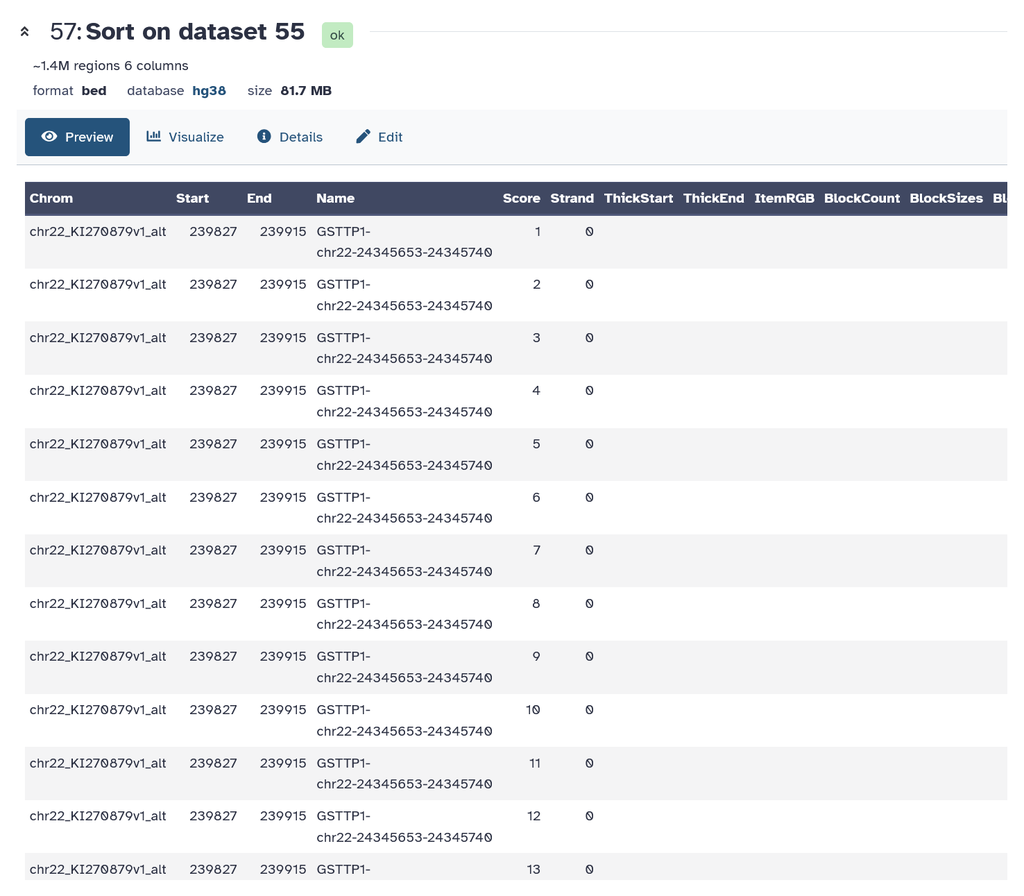

Figure 46: The sorted output of bedtools

### 7.8.3 Targeted Regions Mean Coverage

We can calculate the mean coverage of the targeted regions by averaging over the values in column 6.

14. In the Tool Panel select the `Summary Statistics` tool.
15. For the `Summary statistics on` section select `Dataset collection` as your data type, then select `Sort on collection 54` as your data collection.
16. Set `Column or expression` to `c6`.
17. Click on the `Run Tool` button to execute the analysis.

[figure not shown]

Figure 47: The `Summary Statistics` tool panel with options set

18. View the data. It should look like Figure 48.

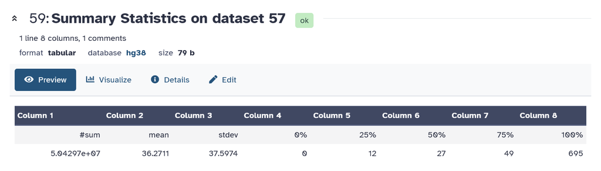

Figure 48: Summary statistics results for depth of targeted regions by the `bed` file

### 7.8.4 Depth of coverage by chromosome

What is the average depth of coverage across the entirety of chromosome 22?

To quickly and efficiently calculate this value, we will be using the mosdepth tool.

19. In the Tool Panel select the `mosdepth` tool.
20. Select `Dataset collection` as your data type, then select `Filter SAM or BAM, output SAM or BAM on collection 23: bam` as your data collection.
21. Click on the `Run Tool` button to execute the analysis.

[figure not shown]

Figure 49: The `mosdepth` tool panel with options set

18. View the `mosdepth summary` file to see the coverage of depth calculated by chromosome. It should look like Figure 50.

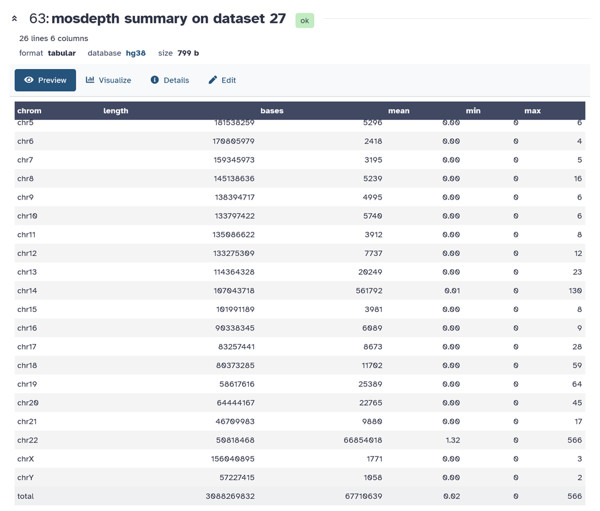

Figure 50: A section of the mosdepth summary report

**Important**

Use the mosdepth report to answer the following questions:

1. What is the mean depth of coverage across the entire chromosome 22?
2. What is the mean depth of coverage across the entire genome?

# 8 Visualising Alignments

**Note**

- **Software**
  - `IGV`
- **Input/Output**
  - `IGV` input:
    - `bam` and `bai` file
    - reference genome (IGV provided)
    - optional additional files
      - vcf from variant calling
      - bed files (gene annotations)
  - `IGV` output:
    - Interactive visual display of data

## 8.1 Integrative Genomics Viewer (IGV)

It is useful to look at the aligned data as this is one way to identify variants, assess their quality, and determine their genomic context with respect to other annotated features of the human genome such as genes, repeat sequences, transcription factor binding sites etc. We therefore recommend alignment visualisation before validation of in-silico variants by independent sequencing methods.

The Integrative Genome Viewer (IGV) is a popular tool for interrogating aligned NGS data (look here for more details on IGV: www.ncbi.nlm.nih.gov/pubmed/22517427).

You can run IGV on its [Web App](https://igv.org/app/). Don’t worry if you accidentally close Galaxy. Your files will remain saved as long as you don’t delete them.

About IGV

## 8.2 Viewing the BAM File

1. Navigate to your filtered `bam` data set `Filter SAM or BAM, output SAM or BAM on collection 23: bam` and open the panel.
2. Download the `Dataset` and the `bam_index`.
3. Rename the `bam` file to `filtered.bam`, and the `bai` index to `filtered.bam.bai`.

**Warning**

The `bam` and `bai` file names should not have special characters for the files to be read successfully by IGV.

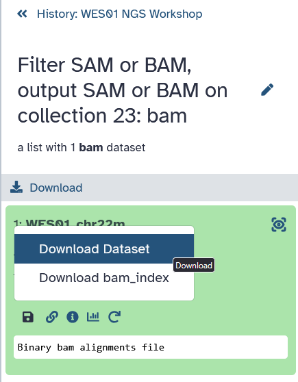

Figure 51: Downloading the filtered `bam` file and index from the history panel

4. Open the [IGV Web App](https://igv.org/app/), and ensure the reference genome is set to `hg38`, on the top left corner. You can change it in the `Genome` drop-down menu if you are currently on a different build.
5. Click on the `Tracks` drop-down menu, and click on `Local File...`.
6. Select the `filtered.bam` and `filtered.bam.bai` files to import the alignment track to IGV.

[figure not shown]

Figure 52: Section of the IGV Web App

## 8.3 Viewing the Gene NF2

7. Enter `NF2` in the search box and click enter to go to this gene. We can now see data for the whole gene as a coverage profile in the upper track and individual reads below.

`NF2` is a tumour suppressor gene that regulates cell cycle, growth and differentiation. An inactivating germline mutation in exon 1 of SMARCB1 has been reported in patients with [NF2-related Schwannomatosis](https://doi.org/10.1016/j.spen.2024.101171). Schwannomas are mostly benign tumours involving schwann cells that myelinate the axons of nerve cells but can cause problems if the tumour compresses a nerve. There are several cases where people with schwannomatosis have developed hearing loss due to an acoustic neuroma, which is a schwannoma on the vestibular nerve in the brain that is involved in hearing.

[figure not shown]

Figure 53: View of the gene `NF2` on IGV

**Important**

What does the coverage look like? Are all exons equally captured?

Zoom in on an exon and get familiar with IGV and viewing the BAM file.

## 8.4 A Variant in NF2

8. Enter the location `chr22:29,642,163` in the search box to focus on the data for a particular variant. You can now see the coloured bar consists of two colours representing the two alleles and their height corresponds with the allele frequency.
9. Right click and select sort alignments by base.
10. Mouse over the coverage track for the SNV at `chr22:29,642,163` and look at the information IGV displays.

[figure not shown]

Figure 54: View of a variant in the gene `NF2` on IGV

# 9 Variant Calling

**Note**

Accurate and consistent variant calling requires statistical modelling and is essential for the clinical implementation of NGS. However, many programs are available for calling variants and their concordance varies. Furthermore, variants have different levels of confidence due to differences in data quality.

For variants with intermediate confidence levels, it is difficult to separate true variation from artefacts that arise from many factors such as sequencing error, misalignment and inaccurate base quality scores. As a result, the evidence for variant calls requires scrutiny and caution should be used when interpreting positive and negative findings especially for indels which are more error prone.

At the end of this exercise you will be able to:

1. Use a state of the art software (`freebayes`) to call small variants (SNVs and indels)
2. Describe the contents of variant call files
3. Generate and interpret basic variant quality control parameters
4. Use quality control filters to exclude or flag variants with low confidence

[Additional Reference](https://galaxyproject.org/learn/galaxy-ngs101/#finding-variants): Finding variants

## 9.1 Freebayes

[Freebayes](https://github.com/freebayes/freebayes) is a Bayesian genetic variant detector designed to find small polymorphisms, specifically SNPs (single-nucleotide polymorphisms), indels (insertions and deletions), MNPs (multi-nucleotide polymorphisms), and complex events (composite insertion and substitution events) smaller than the length of a short-read sequencing alignment.

1. In the Tool Panel select the `freebayes` tool.
2. Select `Dataset collection` as your data type, then select `Filter SAM or BAM, output SAM or BAM on collection 23: bam` as your data collection.
3. On the section `Using reference genome`, select `Human Dec. 2013 (GRch38/hg38)`.
4. Click on the `Run Tool` button to execute the analysis.

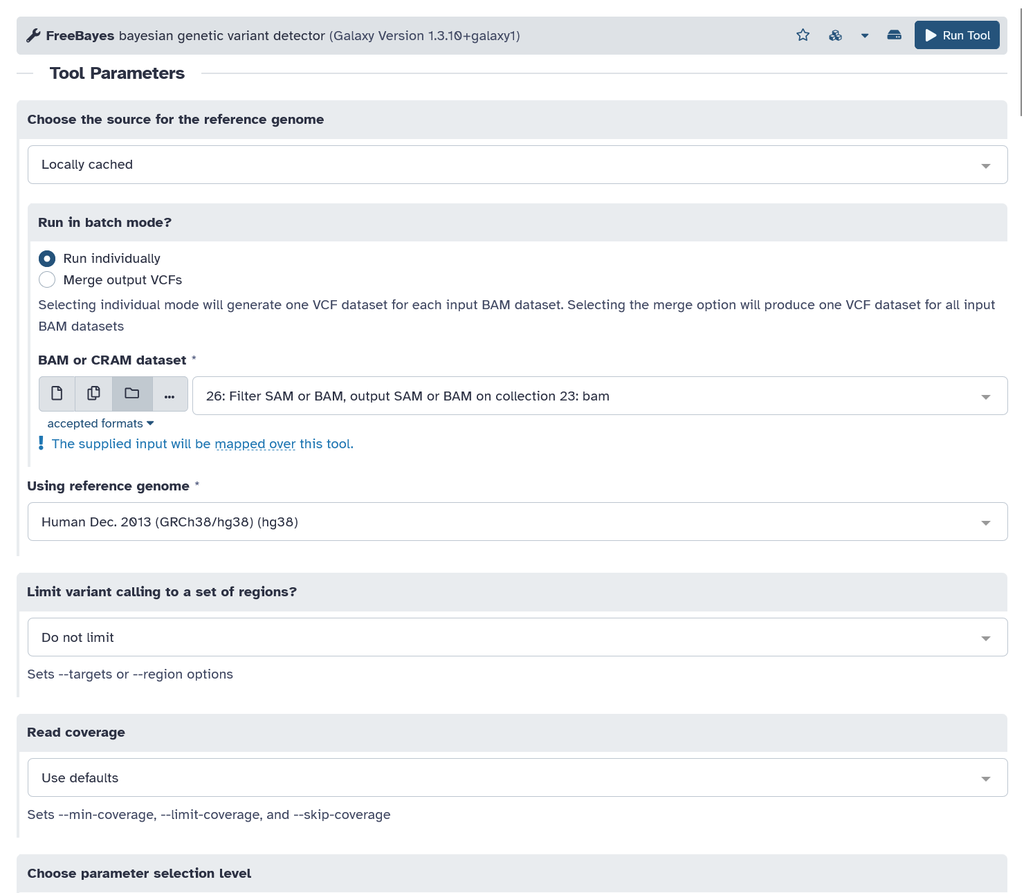

Figure 55: The `freebayes` tool panel with options set

`Freebayes` uses short-read alignments ([BAM](http://samtools.sourceforge.net/SAMv1.pdf) files with [Phred+33](http://en.wikipedia.org/wiki/Phred_quality_score) encoded quality scores, now standard) for any number of individuals from a population and a [reference genome](http://en.wikipedia.org/wiki/Reference_genome) (in [FASTA](http://en.wikipedia.org/wiki/FASTA_format) format) to determine the most-likely combination of genotypes for the population at each position in the reference. It reports positions which it finds putatively polymorphic in variant call file ([VCF](http://www.1000genomes.org/node/101)) format. It can also use an input set of variants (VCF) as a source of prior information, and a copy number variant map (BED) to define non-uniform ploidy variation across the samples under analysis.

## 9.2 Viewing the VCF

**Important**

View the VCF file created by freebayes and familiarise yourself with the variables by reading the comments in the header section.

This history panel shows: 7,044 variants and 516 comments (Figure 56).

The comments appear at the top of the VCF file (lines begin with a ‘#’ character) and explain the format of the info and sample columns.

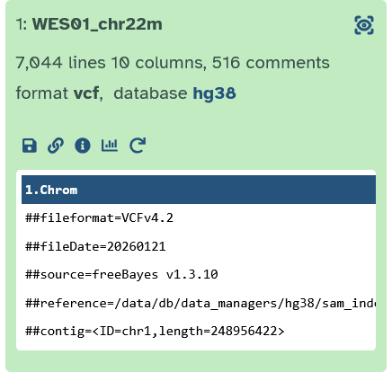

Figure 56: History section of the `vcf` file output from `freebayes`

`Freebayes` emits a standard VCFv4.2 output stream. This format is designed for the probabilistic description of allelic variants within a population of samples, but it is equally suited to describing the probability of variation in a single sample.

Of primary interest to most users is the `QUAL` field, which estimates the probability that the site is polymorphic (i.e. carries an alternate allele). In `freebayes`, this value can be understood as 1 - P(locus is homozygous reference, given the data). It is recommended that users use this value to filter their results, rather than accepting anything output by freebayes as ground truth.

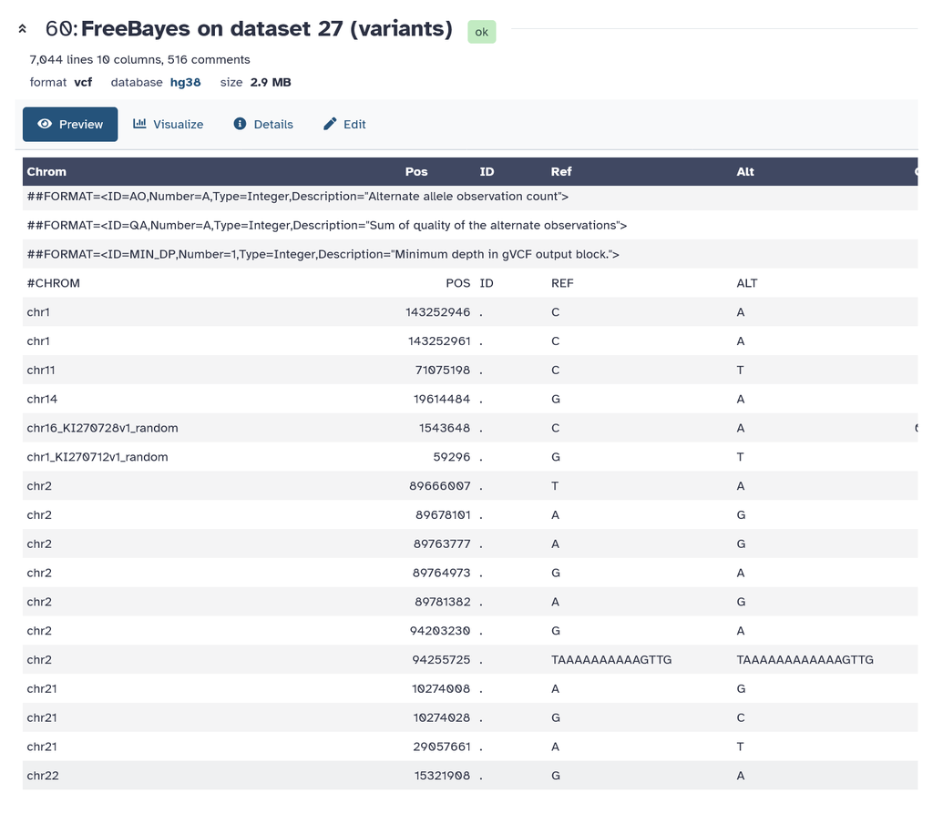

Figure 57: Section of the contents of the `vcf` file output from `freebayes`

## 9.3 Filtering the VCF

By default, VCF records are output even if they have very low probability of variation, in expectation that the VCF will be filtered.

1. In the Tool Panel select the `bcftools view VCF/BCF conversion` tool.
2. Select `Dataset collection` as your data type, then select `FreeBayes on collection 26 (variants)` as your data collection.
3. On the section `Restrict to`, add the following filtering expression to `Include`: `QUAL > 1 && QUAL/INFO/AO > 10 && SAF > 0 && SAR > 0 && RPR > 1 && RPL > 1`
4. Set the `output_type` to `uncompressed VCF`.
5. Click on the `Run Tool` button to execute the analysis.

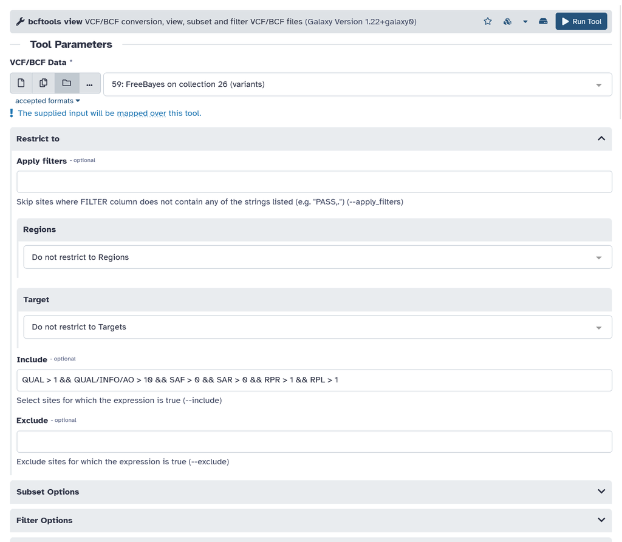

Figure 58: The `bcftools view` tool panel with options set

**The Freebayes Information Fields we used for filtering**

- `QUAL` probability that there is a polymorphism at the loci described by the record: 1 - P(locus is homozygous given the data).
- `AO` Alternate allele observations, with partial observations recorded fractionally.
- `SAF` Number of alternate observations on the forward strand.
- `SAR` Number of alternate observations on the reverse strand.
- `RPL` Reads Placed Left: number of reads supporting the alternate balanced to the left (5’) of the alternate allele.
- `RPR` Reads Placed Right: number of reads supporting the alternate balanced to the right (3’) of the alternate allele.

**What calls do we “know” are poor (w.r.t. freebayes VCFannotations)?** 1. Low-quality calls (QUAL < N) - Variants with low overall quality scores - Additionally, cases where QUAL is high but QUAL/AO (quality per observation) is low 2. Low read depth (DP < N) - Loci with insufficient sequencing coverage 3. Strand bias issues - AF > 0 & SAR > 0: Ensures alternate alleles are seen on BOTH forward and reverse strands - Removes variants only observed on one DNA strand (likely artifacts) 4. Read placement bias - RPL > 0 & RPR > 0: Ensures reads supporting the variant are balanced on both sides

**Suggested freebayes hard filters for diploid Humans**

`QUAL > 1 && QUAL/INFO/AO > 10 && SAF > 0 && SAR > 0 && RPR > 1 && RPL > 1`

- QUAL > 1: removes horrible sites
- QUAL / AO > 10 : additional contribution of each obs should be 10 log units (~ Q10 per read)
- SAF > 0 & SAR > 0 : reads on both strands
- RPR > 1 & RPL > 1 : at least two reads “balanced” to each side of the site

[Additional Reference](https://www.scribd.com/document/415209482/Erik-Garrison-Iowa-Talk-2): freebayes in depth: model, filtering, and walkthrough

**Important**

Look at the filtered `vcf` file. How many variants are there after filtering?

Before

After

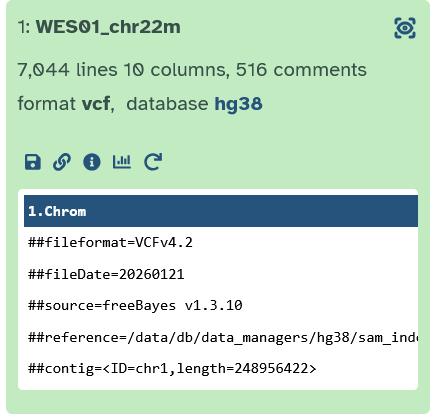

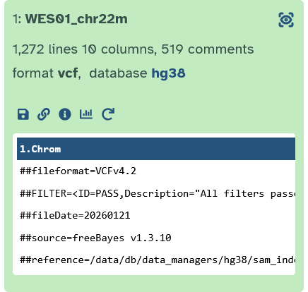

# 10 Variant Annotation and Prioritisation

**Note**

- **Software**
  - `VEP` (Variant Effect Predictor)
- **Input/Output**
  - `VEP` input:
    - vcf file
    - annotation databases
  - `VEP` output:
    - annotated vcf file
    - text file with annotations

At this point in the analysis of whole exome data from patient WES01, we have assessed the quality of raw sequence data, removed low quality reads, aligned sequence data to the reference genome, removed poorly mapped reads and duplicate reads, assessed the alignment process, called variants and evaluated variant calling. The aim of this practical is to complete the analysis of WES01 by annotating the variants and using a filtering strategy to generate a short-list of potentially pathogenic variants. At the end of this exercise you will be able to:

1. Use `VEP` to annotate variants with respect to genes, databases of normal variation, and predictors of pathogenicity
2. Apply basic variant filters to generate a list of candidate genes and likely causative variants
3. Use phenotype information to improve annotation, filtering and prioritisation of likely causative variants

## 10.1 Annotating variants

The result of variant calling is a variant call file (VCF) which describes the location and data quality of each variant. However, the initial VCF file does not provide any information about the functional relevance of variants and their potential contribution to disease. To gain these insights we will use VEP (McLaren et al 2016) to annotate each variant in the VCF file with respect to their location in relation to genes and coding sequences (exon, intron or intergenic), whether they change the coding sequence and if so how (missense, stop gain, synonymous, frameshift, amino acid consequence etc). In addition, we will cross reference the variants with databases of known variation (1000 genomes, dbSNP, Exome Sequencing Project and COSMIC) and predictions of functional significance (avsift and conservation scores).

At this stage, it is important to be aware that the annotation result will vary according to the choice of annotation software (alternative software: SnpEff Cingolani et al 2012; and ANNOVAR Wang et al 2010) and definition of transcripts (Ensemble Flicek et al 2012, RefSeq Pruitt et al 2012, Gencode Harrow et al 2012).

This variability occurs because a single variant may have different effects in different transcripts (isoforms of the gene) and in some cases may effect different genes (genes can overlap, one on forward strand the other on the reverse strand) each with multiple transcripts. It is also possible to interpret a single variant as having multiple effects on a single transcript.

The annotation software must therefore apply a set of rules to determine which variant takes precedence (see [here](http://annovar.openbioinformatics.org/en/latest/user-guide/gene/#output-file-2-refseq-gene-annotation) for the ANNOVAR precedence rules) but these rules vary between programs so that they generate different results.

For example, the overall agreement for Loss of Function (LoF) variants annotated by ANNOVAR and VEP is just 64% (McCarthy et al 2014: [Choice of transcripts and software has a large effect on variant annotation](https://doi.org/10.1186/gm543)).

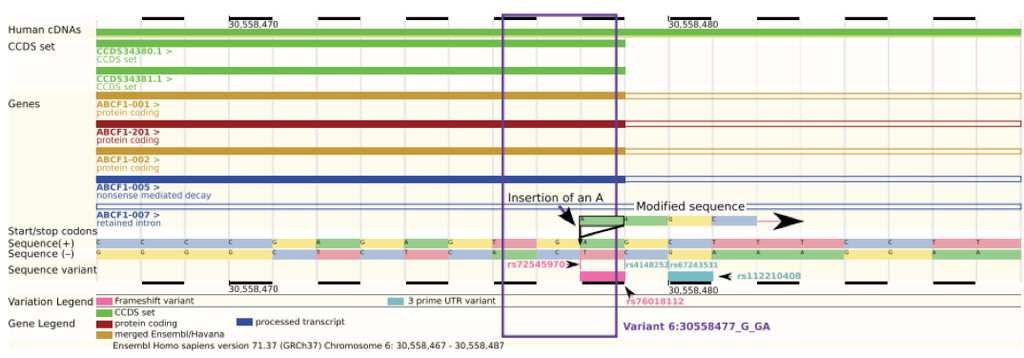

Figure 59: Annotation examples from McCarthy et al 2014

The variant is an insertion of an A in a stop codon (TGA) in the penultimate base of the exon in all transcripts except one. It is possible to interpret this variant as a frameshift insertion or a stop-loss but it is actually a synonymous variant because the stop codon remains in the same place.

The choice of which transcript set to use for annotation has an even bigger effect on the annotation results. For example, the overlap between LoF variants is only 44% when the same software is used to annotate against transcripts from Ensembl or RefSeq (McCarthy et al 2014). This is because RefSeq transcripts are based on a collection of non-redundant mRNA models that have strong support and are manually curated.

As a result, the RefSeq database is highly accurate but does not contain all possible transcripts or gene models (n=41,501 transcripts from RefSeq release 57 that were used by ANNOVAR). In comparison, Ensembl provides a less curated but more comprehensive list of transcripts (n=115,901 transcripts from Ensembl version 69 that were used by ANNOVAR) based on information from the Consensus Coding Sequence (CCDS, Pruitt et al 2009), Human and Vertebrate Analysis and Annotation (HAVANA), Vertebrate Genome Annotation (Vega, Ashurst et al 2005), ENCODE (The ENCODE Project Consortium 2012) and GENCODE (Searle et al 2010).

## 10.2 VEP (Variant Effect Predictor)

[VEP](https://www.ensembl.org/vep) is a rapid, efficient tool to annotate functional consequences of genetic variation from high-throughput sequencing data. VEP also provides easy and intuitive web-based access to the most popular functionalities of the software.

`VEP` will annotate variants using specified gene annotations, regions, and filtering databases. Input is a VCF dataset, and output is a table of annotations for each variant in the VCF dataset or a VCF dataset with the annotations in INFO fields.

[VEP Website](https://www.ensembl.org/vep)

[Paper](https://doi.org/10.1186/s13059-016-0974-4)

[VEP Tutorial](http://www.ensembl.org/info/docs/tools/vep/script/vep_tutorial.html)

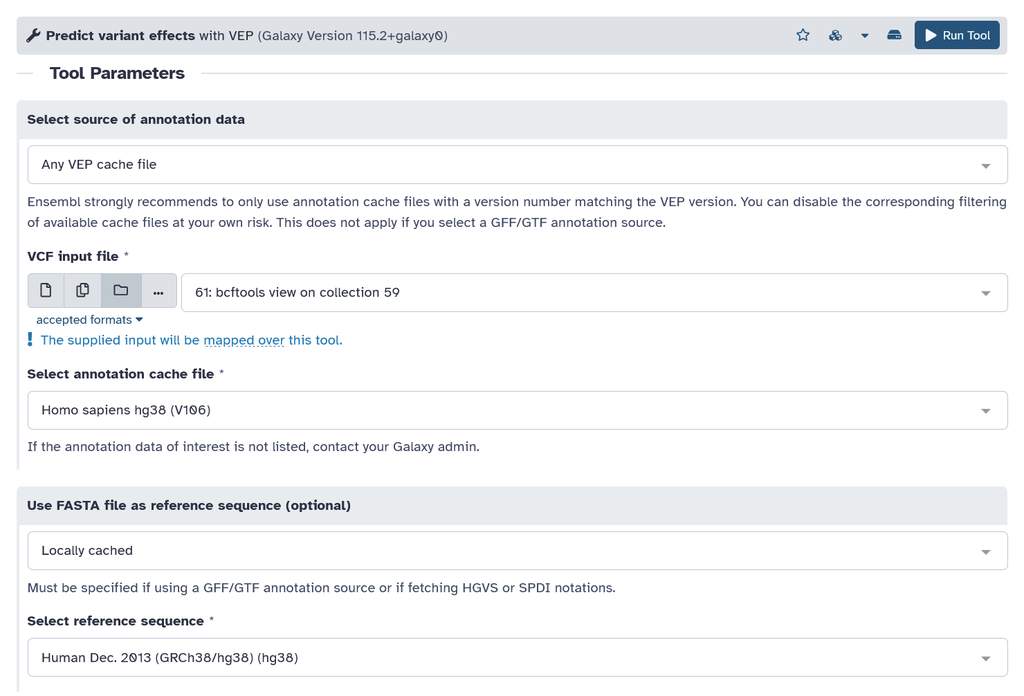

The `VEP` tool panel with main options set

4. On the section `Output options`, set the following options:
   - Output SIFT prediction - `Both`
   - Output PolyPhen prediction - `Both`

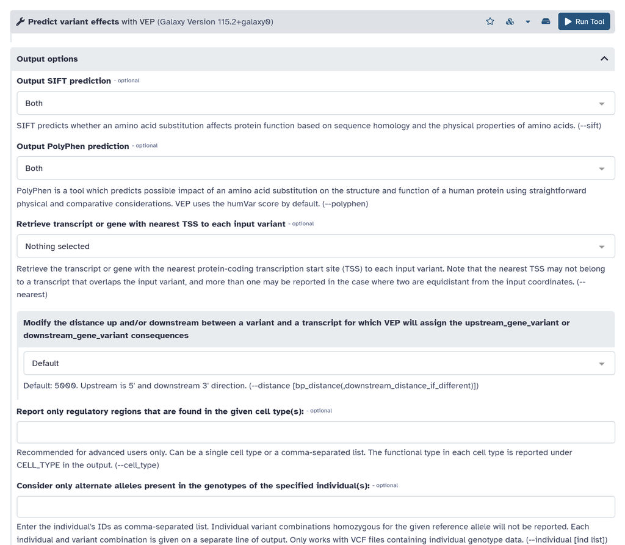

Figure 60: The `VEP` tool panel with `Output options` set

5. On the section `Identifiers`, enable the following `Identifier flags`:
   - Add HGVS nomenclature, both coding and protein sequence names, to the ouput (requires FASTA)
   - Add the gene symbol (e.g. HGNC) (where available) to the output
   - Add a flag indicating if the transcript is the canonical transcript for the gene
   - Add a flag indicating if the transcript is the MANE Select or MANE Plus Clinical transcript for the gene (only for hg38)
   - Output the biotype of the transcript or regulatory feature
6. On the section `Co-located variants`, enable the following `Co-located variants flags`:
   - Report all known clinical significance values at the given locus (instead of allele-specific)
   - Add the global allele frequency (AF) from 1000 Genomes Phase 3 data for any known co-located variant to the output (–af)
   - Report the highest allele frequency observed in any population from 1000 genomes, ESP or gnomAD
7. On the section `Filtering and QC options`, enable the following `Filtering and QC flags`:
   - Only return consequences that fall in the coding regions of transcripts
8. Click on the `Run Tool` button to execute the analysis.

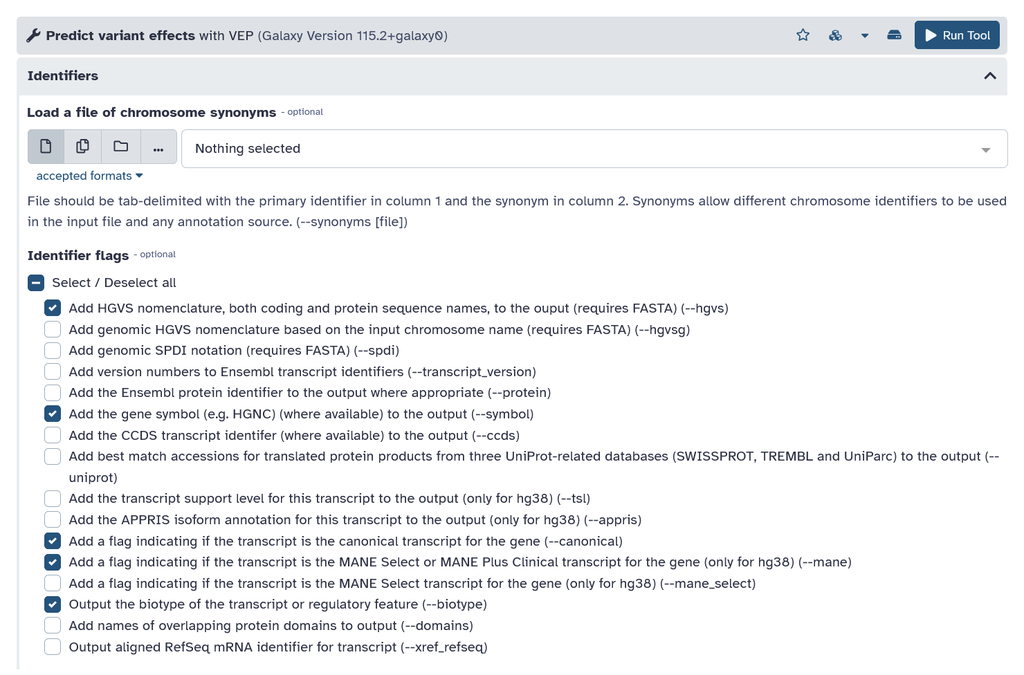

Figure 61: The `VEP` tool panel with `Identifier flags` set

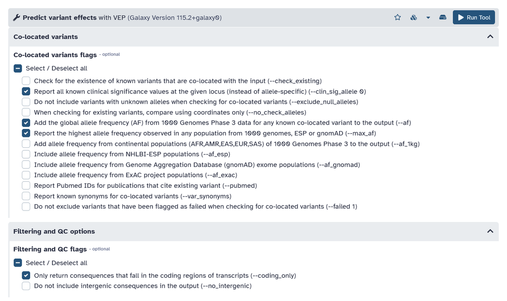

Figure 62: The `VEP` tool panel with `Co-located variants flags` and `Filtering and QC flags` set

### 10.2.1 Variant Effect Prediction algorithms

**Tip**

If you’re running out of time to finish the workshop you can read the section below in your own time and skip to the last section on how to create a workflow.

[Reference](https://www.ensembl.org/info/docs/tools/vep/online/input.html#prediction)

Below you can see outlined different prediction algorithms used by variant prediction software.

**SIFT predictions** SIFT predicts whether an amino acid substitution affects protein function based on sequence homology and the physical properties of amino acids. Only available in popular species. For both SIFT and PolyPhen Ensembl VEP can report either a score between 0 and 1, a prediction in words, or both.

**Polyphen-2** Polyphen-2 predicts the impact of an amino acid substitution on the structure and function of a protein. Predictions are based on features that characterise the substitution including the sequence (does the substitution occur within an annotated site in the protein e.g. active or binding site, non-globular region such as trans-membrane etc), phylogenetics (how often does the substitution occur in a family of related proteins) and structural information (could the substitution affect the proteins 3D structure e.g. hydrophobic core, electrostatic interactions, interactions with ligands or other important features). These features are assessed by a probabilistic classifier. Two versions of Polyphen are available, HDIV and HVAR, that used different datasets to train and test the prediction models. HDIV should be used for evaluating rare alleles involved in complex phenotypes where both disease causing and mildly deleterious alleles are treated as damaging. The HDIV dataset consists of all damaging alleles in the UniProtKb database that effect molecular function and cause human Mendelian diseases versus differences between human proteins and their closely related mammalian homologues which are assumed to be non-damaging.

**HVAR** should be used for diagnostics of Mendelian diseases which requires distinction between mutations with diagnostic effects from all remaining human variation, including a wealth of mildly deleterious alleles. The HVAR dataset used to train and test Polyphen consisted of all human disease causing mutations from UniProtKb together with common human non-synonymous SNPs (MAF>1%) without annotated involvement in disease which were treated as non-damaging.

**LRT score** Likelihood ratio test (LRT) for prediction of significantly conserved amino acid positions within the human proteome. Mutations are estimated as ‘deleterious’ that disrupt highly conserved aminoacid residues, ‘neutral’ or ‘unknown’.

**Mutation Taster** MutationTaster uses a Bayes classifier to predict the disease potential of an alteration. For this prediction, the frequencies of all single features for known disease mutations/polymorphisms were studied in a large training set composed of >390,000 known disease mutations from HGMD Professional and >6,800,000 harmless SNPs and Indel polymorphisms from the 1000 Genomes Project.

**Mutation Assessor** Mutation assessor scores estimate functional impact based on evolutionary conservation of the affected amino acids in protein homologs. The method has been validated on a large set (60k) of disease associated (OMIM) and polymorphic variants.

**FATHMM score** Functional Analysis through Hidden Markov Models. Predicts the functional effects of protein missense mutations by combining sequence conservation within hidden Markov models (HMMs), representing the alignment of homologous sequences and conserved protein domains, with “pathogenicity weights”, representing the overall tolerance of the protein/domain to mutations.

**RadialSVM** Support vector machine (SVM) based ensemble prediction score, which incorporates 10 scores (SIFT, PolyPhen-2 HDIV, PolyPhen-2 HVAR, GERP++, MutationTaster, Mutation Assessor, FATHMM, LRT, SiPhy, PhyloP) and the maximum frequency observed in the 1000 genomes populations. Larger value means the SNV is more likely to be damaging. Scores range from -2 to 3 in dbNSFP.

**LR score** LR scores evaluate the deleteriousness of missense mutations by using logistic regression to integrate information from:

1. function prediction scores (PolyPhen-2, SIFT, MutationTaster, Mutation Assessor, FATHMM, LRT, PANTHER, PhD-SNP, SNAP, SNPs&GO, and MutPred)
2. conservation scores (GERP++, SiPhy and PhyloP)
3. ensemble scores (CADD, PON-P, KGGSeq and CONDEL)
4. maximum minor allele frequency

**VEST3 score** Variant Effect Scoring Tool (VEST) is a supervised machine learning-based classifier for prioritisation of rare missense variants with likely involvement in human disease. The VEST classifier training set comprised ~ 45,000 disease mutations from the latest Human Gene Mutation Database release and another ~45,000 high frequency (allele frequency >1%) putatively neutral missense variants from the Exome Sequencing Project. VEST estimates variant score p-values against a null distribution of VEST scores for neutral variants not included in the VEST training set. These p-values can be aggregated at the gene level across multiple disease exomes to rank genes for probable disease involvement.

**CADD raw** Combined Annotation Dependent Depletion (CADD) is a framework that integrates multiple annotations into one metric by contrasting variants that survived natural selection (differences between 1000 Genomes and the Ensembl Compara inferred human-chimpanzee ancestral genome) with simulated mutations. Raw CADD scores come straight from the model and have no absolute unit of meaning and are incomparable across distinct annotation combinations, training sets, or model parameters. However, raw values have relative meaning with larger scores indicating that a variant is more likely to have a damaging effect.

**CADD phred** Phred CADD scores are ranked scores based on the whole genome CADD raw scores. For example, variants at the 10th-% of raw CADD scores are assigned to CADD-10, top 1% to CADD-20, top 0.1% to CADD-30, etc. The results of this transformation are Phred-like scaled CADD scores.

**Genomic Evolutionary Rate** Profiling Rejected Substitution scores (GERP RS). GERP identifies constrained elements in multiple alignments by quantifying substitution deficits for SNPs. Scores range from -12.3 to 6.17, with 6.17 being the most conserved. Scores greater than 2 provide a high sensitivity while still strongly enriched for truly constrained sites.

**PhyloP46way placental** Phylogenetic conservation score based on a multiple alignment of 46 vertebrate genomes (10 primates, 33 placental mammals).

**PhyloP100way vertebrate** Phylogenetic conservation score based on a multiple alignment of 100 vertebrate genomes.

**SiPhy 29way logOdds** The estimated stationary distribution of A, C, G and T at the site, using SiPhy algorithm based on 29 mammals genomes.

## 10.3 Filtering and Prioritisation of variants

There are many ways to filter the variants. One of the most common strategies is to select coding variants that are either rare or absent from databases of known variation such as [1000 Genomes](https://www.internationalgenome.org/) and [gnomAD](https://gnomad.broadinstitute.org) and predicted to be damaging by in-silico tools.

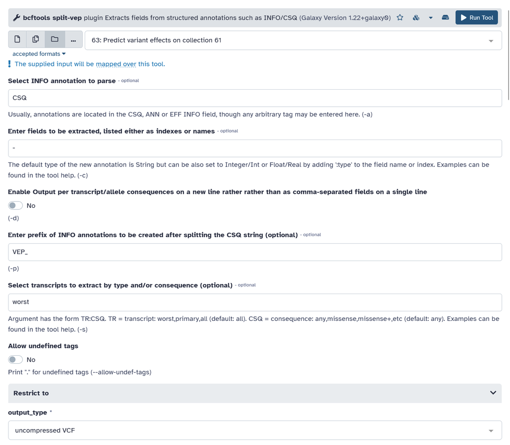

Figure 63: The `bcftools split-vep` tool panel with options set

Now let’s convert the vcf file into a tabular format, so it is easier to read.

   ```
    %CHROM\t%POS\t%VEP_SYMBOL\t%VEP_Feature\t%VEP_HGVSc\t%VEP_HGVSp\t%VEP_Consequence\t%VEP_IMPACT\t%VEP_CLIN_SIG\t%VEP_Existing_variation\t%VEP_AF\t%VEP_MAX_AF\t%VEP_PolyPhen\t%VEP_SIFT\t%VEP_CANONICAL\t%VEP_MANE_SELECT\n
   ```

4. Enable `Output is tab-delimited`.
5. Click on the `Run Tool` button to execute the analysis.

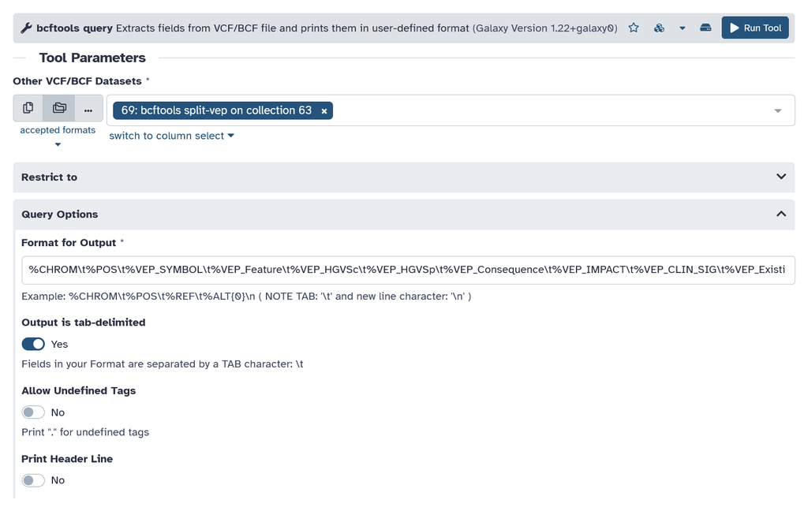

Figure 64: The `bcftools query` tool panel with options set

Here is a breakdown of what each column represents in your output file.

| Col | Field | Description |
| --- | --- | --- |
| 1 | CHROM | Chromosome name (e.g., `chr1`, `X`). |
| 2 | POS | Genomic coordinate (1‑based position). |
| 3 | VEP_SYMBOL | Official gene symbol (HGNC), e.g., `BRCA1`, `TP53`. |
| 4 | VEP_Feature | Transcript ID (usually Ensembl `ENST…`); `-s worst` shows the most severe transcript. |
| 5 | VEP_HGVSc | Coding DNA change (e.g., `c.152A>G`). |
| 6 | VEP_HGVSp | Protein change (e.g., `p.Lys51Arg` or `p.L51R`); empty if non-coding. |
| 7 | VEP_Consequence | Consequence type (e.g., `missense_variant`, `stop_gained`). |
| 8 | VEP_IMPACT | VEP severity: `HIGH`, `MODERATE`, `LOW`, `MODIFIER`. |
| 9 | VEP_CLIN_SIG | ClinVar significance (`pathogenic`, `likely_pathogenic`, `benign`, etc.). |
| 10 | VEP_Existing_variation | dbSNP rsID (e.g., `rs12345`). |
| 11 | VEP_AF | Global allele frequency (from 1000 Genomes). |
| 12 | VEP_MAX_AF | Max allele frequency across subpopulations (important to validate rarity). |
| 13 | VEP_PolyPhen | PolyPhen prediction (`probably_damaging`, `possibly_damaging`, `benign`). |
| 14 | VEP_SIFT | SIFT prediction (`deleterious` or `tolerated`). |
| 15 | VEP_CANONICAL | `YES` if the transcript is Ensembl canonical. |
| 16 | VEP_MANE_SELECT | MANE Select transcript (e.g., `NM_` number) if available. |

## 10.4 Solving the Case Study

The sequence data that you will be analysing is from a 3-year-old male who presented with difficulty walking after the first year of life, followed by muscle wasting and weakness, muscle rigidity, developmental delay, progressive vision loss leading to blindness, seizures, impaired swallowing, paralysis, and cognitive decline.

A brain MRI scan showed a “tigroid” (leopard‑skin) pattern within the deep white matter. Further clinical testing suggested a diagnosis of [Metachromatic leukodystrophy](https://medlineplus.gov/genetics/condition/metachromatic-leukodystrophy/) (MLD, also called Arylsulfatase A deficiency), which is a lysosomal storage disease commonly listed in the family of leukodystrophies as well as among the sphingolipidoses as it affects the metabolism of sphingolipids.

**Important**

Based on the patients phenotypes and clinical diagnosis, which of the variants in your report do you think is the causative mutation?

The 1000 Genomes database is relatively small. Enter the [gnomAD](https://gnomad.broadinstitute.org/) and validate how rare the variant you chose is on this database.

Can you find this variant on [ClinVar](https://www.ncbi.nlm.nih.gov/clinvar)? NM_000487.6(ARSA):c.346C>T (p.Arg116Ter)?

For the causal variant use the VCF file from Freebayes and look at the Quality score and other fields used for filtering.

If you didn’t have detailed phenotype information and/or the diagnosis, would you have come to the same conclusion?

## 10.5 View the ARSA chr22:50627285 stop gain SNV on IGV

1. Download the bam file `Download dataset` and bam index `Download bam_index`
2. Download the Freebayes vcf file
3. Upload them to IGV

[figure not shown]

Figure 65: View of the `ARSA` gene on IGV

1. View the chr22:50627285 variant on IGV

[figure not shown]

Figure 66: View of the `ARSA chr22:50627285` stop gain variant on IGV

# 11 Reporting with MultiQC

`MultiQC` collates outputs from the QC and alignment tools used in this workflow (falco, fastp, Picard, samtools, mosdepth, etc.) into a single interactive HTML report. Use `MultiQC` to summarise key metrics, and produce a concise, shareable QC overview for reports and presentations.

1. In the Tool Panel select the `MultiQC` tool.
2. For the option `Which tool was used generate logs?` select the relevant tools we used in this workflow. Some tools you also need to select the `Type of output`. Add as many Results sections as needed with the `Insert Results` button until you have added the following reports:
- `FastQC`
  - Raw data
- `fastp`
  - JSON report
- `samtools`
  - `flagstat`
  - `idxstats`
- `Picard`
  - `Markdups`
  - `Insert size`
1. Add the relevant metrics files to each section.
2. Click on the `Run Tool` button to execute the analysis.

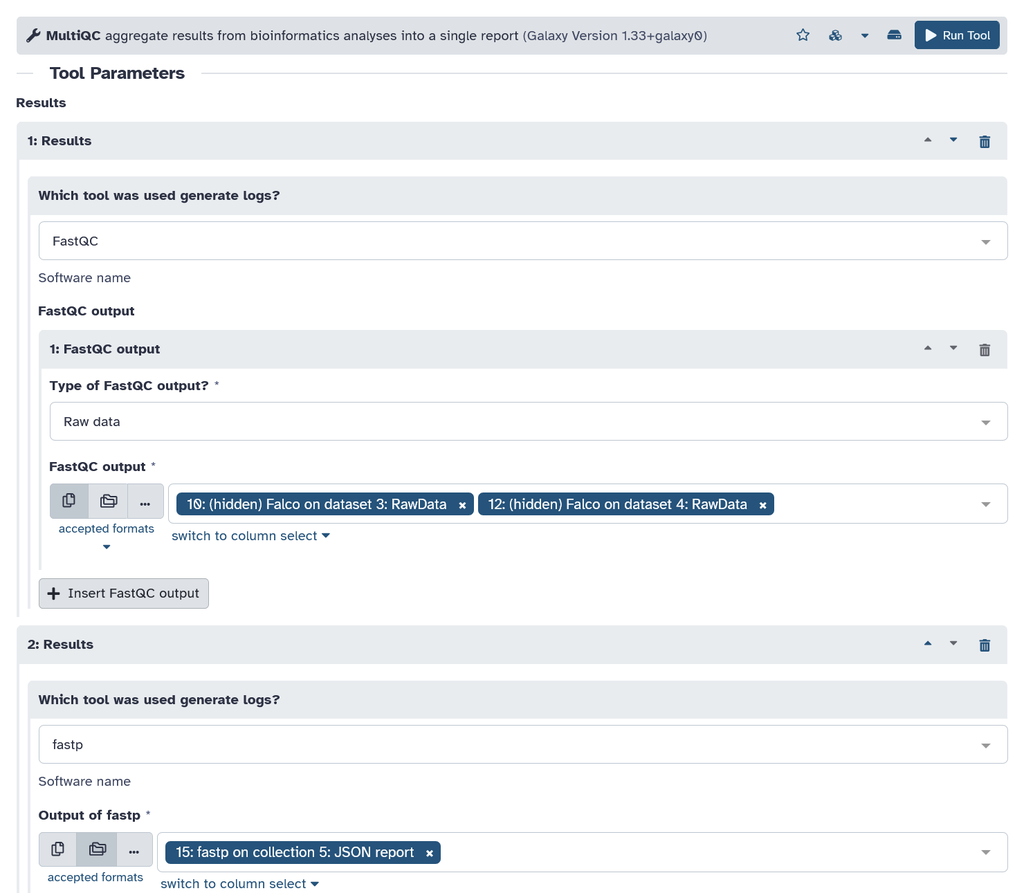

Figure 67: The `MultiQC` tool panel with options set

Explore the MultiQC report you just generated. Open the HTML report in a web browser and interact with the plots and tables:

- Hover plots for tooltips, click legend entries to hide/show series, and use the search/filter boxes to focus on metrics.
- Export tables as CSV (use the export button) and take screenshots of any plots or warnings you plan to discuss.

# 12 Sharing and publishing your work

**Important**

For part of the assessment, you will share your history and workflows with the examiner by submitting them as web links in your NGS report.

We will now learn how to share your current history and workflows.

## 12.1 Create and apply a workflow from your Galaxy history

Please work through and read the Galaxy Guide on how to create a workflow: [Creating Workflows and Advanced Workflow Options](https://galaxyproject.org/learn/advanced-workflow/)

Reproducing an experiment on the same data or different datasets and comparing the results is a key feature of research that requires keeping a meticulous set of instructions. In many cases, multiple replicates are required and the best approach is an automated analysis that is consistent and less error prone. In Galaxy, the history acts as a detailed list of experimental instructions that can be reproduced and automated by creating a ‘Workflow’ or bioinformatic pipeline.

**Important**

Before making your workflow delete any unwanted steps from the history so that it only includes the steps needed to make the final result.

1. Go to the History panel, click the `History Options ≡` and select `Extract workflow`.

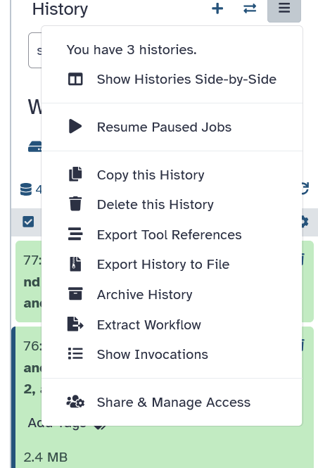

Figure 68: The `History Options` panel

See [Extract Workflow from a History](https://wiki.galaxyproject.org/Learn/AdvancedWorkflow/Extract) and follow the instructions there.

Name your workflow : `Alignment_Variant_Calling_and_Filtering-v0.1` (or something similar, maybe add your initials).

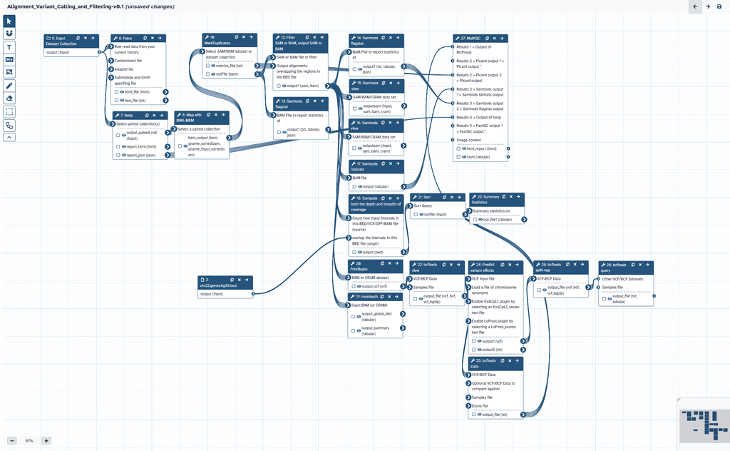

Figure 69: An example of a workflow

## 12.2 Running workflows

Now that you have made a workflow/bioinformatic pipeline you can apply the whole process to a new dataset with just a few clicks. Try your workflow on the original fastq files.

1. In the history panel click the cog icon and select ‘Create New’ to make a new history.
2. Before running the workflows, we need to put the raw data files into the new history. You can do this by uploading or copying the data from an existing dataset. We will copy the input files by clicking the cog icon and selecting ‘Copy Datasets’
3. Select ‘WES01 NGS Workshop’ as the source history and the new ‘Unnamed history’ as the destination.
4. Check the boxes for the 2 inputs that we need:
   1. `WES01 fastq` file collection
   2. `chr22.genes.hg38.bed` target `bed` file
5. Click on `Copy History Items`.
6. Click the workflow tab then click your `‘Alignment_Variant_Calling_and_Filtering’` workflow and select run from the drop down menu.
7. Now choose the relevant input files and click ‘Run workflow’ to analyse the data.

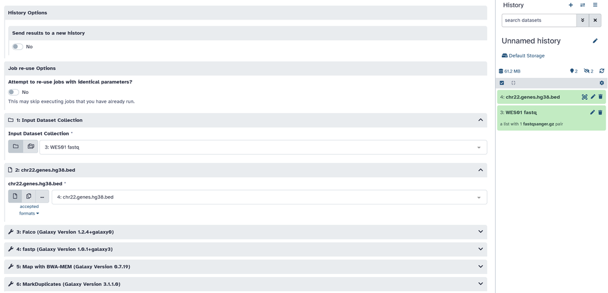

Figure 70: The Galaxy Workflow Run form

8. When the workflow has finished view the output and check that the result matches your original analysis.

## 12.3 Sharing Galaxy Histories and Workflows

**Important**

1. To share your history, click the `History Options` and select `Share & Manage Access`.

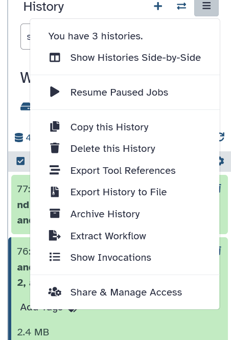

Figure 71: The `History Options` panel

**Important**

2. Enable `Make History Accessible`. This will generate a link that you can share with others so they can import your history into their Galaxy account.

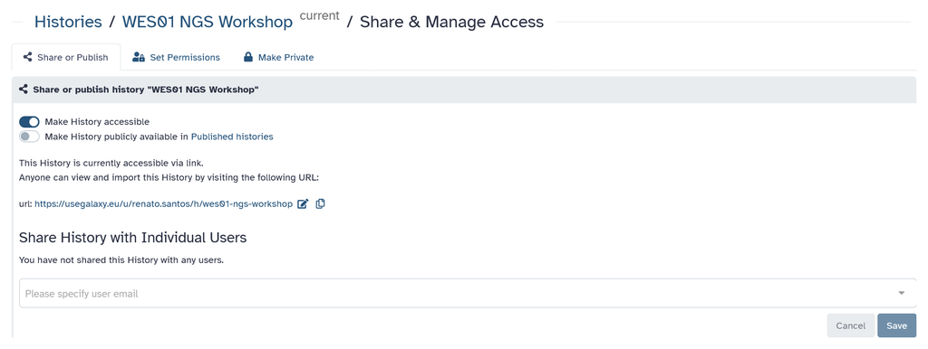

Figure 72: The `Share & Manage Access` menu, with `Make History Accessible` enabled

**Important**

4. To share your workflow, click the workflow tab, then click your workflow and select ‘Share or Download’ from the drop down menu.

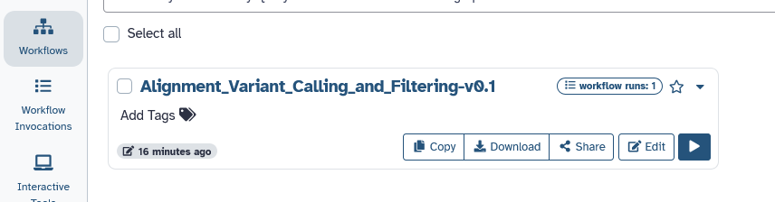

Figure 73: The `Workflow` panel

**Important**

5. Click ‘Make workflow Accessible via Link’ to generate a web link that can be used by others to import your workflow and apply it to their own data.

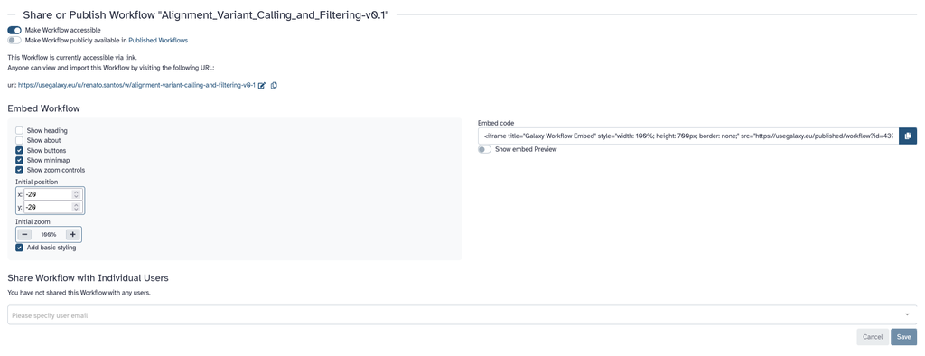

Figure 74: The `Share Workflow` menu, with `Make Workflow Accessible` enabled

# 13 Acknowledgments

Based on a workshop produced by Will Tapper, University of Southampton, and Stephen Newhouse, King’s College London (2016)